# MB590-012 Microbiome Analysis

Christine V. Hawkes

March 2, 2021

# Topic: EXPLORATORY ANALYSIS - CORE MICROBIOMES

```
References:
Risley (2020) Applying the core microbiome to understand host-microbe systems. J Animal Ecology 89: 1549-1558. DOI: 10.1111/1365-2656.13229

Shade & Stopnisek (2019)Abundance-occupancy distributions to prioritize plant core microbiome membership. Curr Op Microbio 49: 50-58. DOI: 10.1016/j.mib.2019.09.008

Data: Oono et al. (2020) Species diversity of fungal endophytes across a stress gradient for plants. New Phytologist 228: 210-225. DOI: 10.1111/nph.16709
```

# SETUP

## Load and install R packages

```r
library(phyloseq)
library(microbiome)
library(ggplot2)
library(tidyverse)
library(compositions)
library(rmarkdown)
library(knitr)
library(Biostrings)
library(vegan)

#install.packages("RColorBrewer")
library(RColorBrewer)
#install.packages("reshape2")
library(reshape2)
#devtools::install_github("Russel88/MicEco")
library(MicEco)
```

## Load and prepare data

All files are on GitHub, add the raw url path to the read commands.

### OTU table

```r
OTU_data <- read.csv("wk8_97OTU_table.csv", stringsAsFactors=FALSE, row.names=1, header=TRUE)
# str(OTU_data)
# anyNA(OTU_data)
colnames(OTU_data) # taxa are rows!
```

```
##  [1] "T1P10" "T1P1"  "T1P2"  "T1P3"  "T1P4"  "T1P5"  "T1P6"  "T1P7"  "T1P8"
## [10] "T1P9"  "T2P10" "T2P1"  "T2P2"  "T2P3"  "T2P5"  "T2P8"  "T2P9"  "T2V10"
## [19] "T2V1"  "T2V2"  "T2V3"  "T2V4"  "T2V5"  "T2V6"  "T2V7"  "T2V8"  "T2V9"
## [28] "T3P10" "T3P1"  "T3P2"  "T3P3"  "T3P4"  "T3P5"  "T3P6"  "T3P7"  "T3P8"
## [37] "T3P9"  "T3V10" "T3V1"  "T3V2"  "T3V3"  "T3V4"  "T3V5"  "T3V6"  "T3V7"
## [46] "T3V8"  "T3V9"  "T4P10" "T4P1"  "T4P2"  "T4P3"  "T4P4"  "T4P5"  "T4P6"
## [55] "T4P7"  "T4P8"  "T4P9"  "T4V10" "T4V1"  "T4V2"  "T4V3"  "T4V4"  "T4V6"
## [64] "T4V8"  "T4V9"  "T5P10" "T5P1"  "T5P2"  "T5P3"  "T5P4"  "T5P5"  "T5P6"
## [73] "T5P7"  "T5P8"  "T5P9"  "T5V10" "T5V1"  "T5V2"  "T5V3"  "T5V4"  "T5V5"
## [82] "T5V6"  "T5V7"  "T5V8"  "T5V9"
```

### Sample/environmental data

```r
SAM_data <- read.csv("wk8_EnvDataAll.csv", row.names=1, header=TRUE, sep=",")
# str(SAM_data) # check for treatment factors and continuous numeric vars
SAM_data[1,]
```

```
##      Terrace Species Replicate EcoType Carbon Nitrogen Phenolics Aluminum Boron
## T1P1       1   Pinus         1     T1P  43.69     1.08       1.8   595.98    21
##      Calcium Cadmium Copper Iron Potassium Magnesium Manganese Molybdenum
## T1P1 2666.47    0.09   6.42 54.1   7562.62   1776.28    292.93       0.71
##       Sodium Phosphorus Lead  Sulfur Silicon  Zinc Degrees_long Min_long
## T1P1 1444.15    1722.58 0.23 1309.67   30.26 10.89           39       22
##      Sec_long Decimals_Lat Degrees_long.1 Min_long.1 Sec_long.1 Decimals_Long
## T1P1       39      39.3775            123         48         54      -123.815
```

```r
anyNA(SAM_data)# will need to keep an eye on these NAs
```

```
## [1] TRUE
```

### Taxonomy table

```r
TAX_data <- read.csv("wk8_97Taxa.csv", row.names=1, header=TRUE, sep=",")
TAX_data <- as.matrix(TAX_data)
# str(TAX_data)
TAX_data[1,]
```

```
##            Phylum            ClassI             Class             Order
##      "Ascomycota" "Arthoniomycetes" "Arthoniomycetes"   " Roccellaceae"
##            Family
##       " Sigridea"
```

### References sequences for OTUs

```r
REF_data <- Biostrings::readDNAStringSet("wk8_Fungi_seq.fasta", format="fasta")
str(REF_data)
```

```
## Formal class 'DNAStringSet' [package "Biostrings"] with 5 slots
##   ..@ pool           :Formal class 'SharedRaw_Pool' [package "XVector"] with 2 slots
##   .. .. ..@ xp_list                    :List of 1
##   .. .. .. ..$ :<externalptr>
##   .. .. ..@ .link_to_cached_object_list:List of 1
##   .. .. .. ..$ :<environment: 0x0000000026afafd8>
##   ..@ ranges         :Formal class 'GroupedIRanges' [package "XVector"] with 7 slots
##   .. .. ..@ group          : int [1:1193] 1 1 1 1 1 1 1 1 1 1 ...
##   .. .. ..@ start          : int [1:1193] 1 273 569 810 1084 1411 1648 2014 2280 2561 ...
##   .. .. ..@ width          : int [1:1193] 272 296 241 274 327 237 366 266 281 242 ...
##   .. .. ..@ NAMES          : chr [1:1193] "OTU1" "OTU2" "OTU3" "OTU4" ...
##   .. .. ..@ elementType    : chr "ANY"
##   .. .. ..@ elementMetadata: NULL
##   .. .. ..@ metadata       : list()
##   ..@ elementType    : chr "DNAString"
##   ..@ elementMetadata: NULL
##   ..@ metadata       : list()
```

### Make phyloseq object

```r
ASV <- phyloseq::otu_table(OTU_data, taxa_are_rows = TRUE)
SAM <- phyloseq::sample_data(SAM_data)
TAX <- phyloseq::tax_table(TAX_data)
REF <- phyloseq::refseq(REF_data)


ps <- phyloseq::phyloseq(ASV, SAM, TAX, REF)
ps
```

```
## phyloseq-class experiment-level object
## otu_table()   OTU Table:         [ 1193 taxa and 85 samples ]
## sample_data() Sample Data:       [ 85 samples by 31 sample variables ]
## tax_table()   Taxonomy Table:    [ 1193 taxa by 5 taxonomic ranks ]
## refseq()      DNAStringSet:      [ 1193 reference sequences ]
```

### Remove singletons

```r
# remove singletons
ps_nosing <- phyloseq::prune_taxa(phyloseq::taxa_sums(ps) > 1, ps)
phyloseq::ntaxa(ps_nosing)
```

```
## [1] 1192
```

# DATA TRANSFORMATIONS

```r
# microbiome::core requires ASVs to be in relative abundance
ps_ra <- microbiome::transform(ps_nosing, "compositional")

# Some approaches require a clr transformation
# ps_nosing_clr <- microbiome::transform(ps_nosing, transform="clr")
```

# CORE MICROBIOME

We’ll use `microbiome::core` to identify core taxa in the ps object.  
Can adjust two parameters:

- `detection` = relative abundances of the ASVs
- `prevalence` = proportion of samples in which the ASVs are present

### Explore the potential core with a Venn diagram

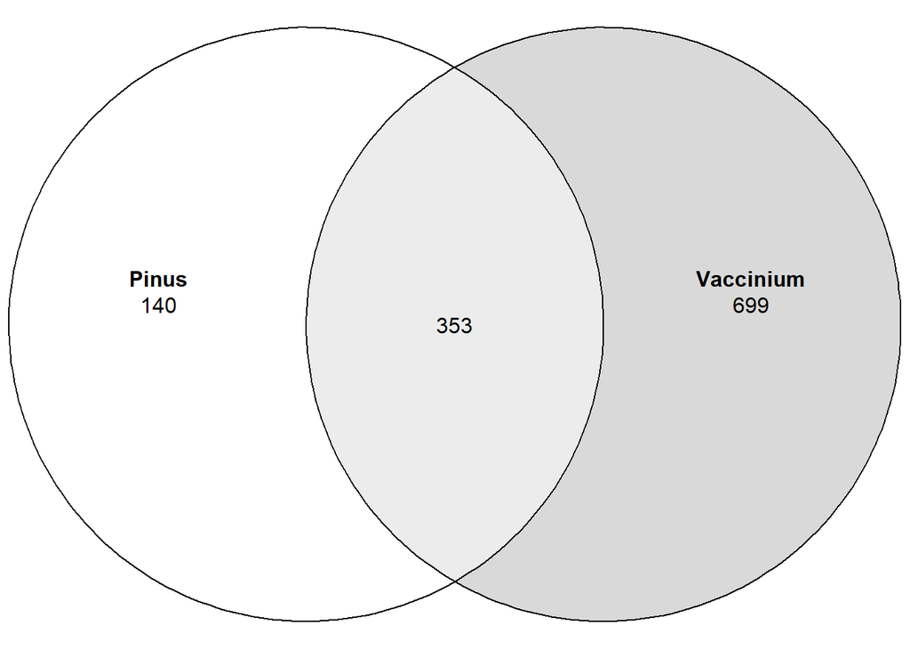

```r
p1 <- MicEco::ps_venn(ps_ra, "Species", fraction=0, weight=FALSE, type="counts", relative=FALSE, plot=TRUE)
# if you set plot=FALSE, can get a list of taxa
p1
```

### Explore prevalence and abundance

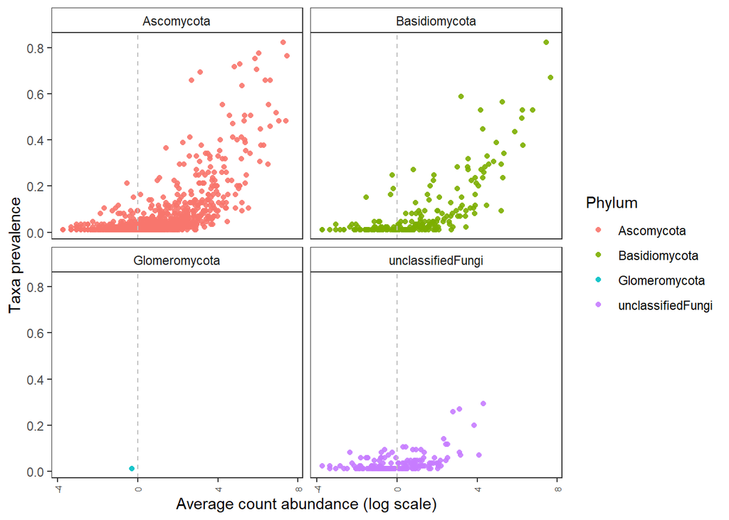

```r
# plot prevalence as a function of log(counts)
microbiome::plot_taxa_prevalence(ps_nosing, "Phylum", detection = 0/100)
```

```r
# make table of taxa with >1% detection (rel abund) threshold
# use kable to get tabular format
# head limits to first 5 rows
taxa.prev <- knitr::kable(head(microbiome::prevalence(ps_ra, detection = 1/100, sort=TRUE)))
taxa.prev
```

|  | x |
| --- | --- |
| OTU1 | 0.5764706 |
| OTU5 | 0.5294118 |
| OTU9 | 0.5058824 |
| OTU16 | 0.4588235 |
| OTU3 | 0.3411765 |
| OTU40 | 0.3176471 |

### Identify core members based on detection and prevalence

Core taxa defined as present in >50% of samples at any rel abund (>0)  
Use `core_members` on ps object to identify core taxa

```r
core.taxa1 <- microbiome::core_members(ps_ra, detection = 0, prevalence = 50/100)
core.taxa1
```

```
##  [1] "OTU4"    "OTU5"    "OTU1"    "OTU16"   "OTU2"    "OTU215"  "OTU9"
##  [8] "OTU18"   "OTU12"   "OTU19"   "OTU442"  "OTU3008" "OTU40"   "OTU46"
## [15] "OTU21"   "OTU3828" "OTU3550" "OTU589"  "OTU675"  "OTU72"   "OTU183"
## [22] "OTU1537" "OTU1336" "OTU3747" "OTU3052"
```

Core taxa defined as present in >50% of samples with >1% rel abundance Use `core_members` on ps object to identify core taxa

```r
core.taxa2 <- microbiome::core_members(ps_ra, detection = 1/100, prevalence = 50/100)
core.taxa2
```

```
## [1] "OTU5" "OTU1" "OTU9"
```

Core taxa defined as present in >50% of samples with >0.1% rel abundance Use `core` to generate new ps object with only core taxa

```r
ps_core <- microbiome::core(ps_ra, detection = 0.1/100, prevalence = 50/100)
ps_core
```

```
## phyloseq-class experiment-level object
## otu_table()   OTU Table:         [ 10 taxa and 85 samples ]
## sample_data() Sample Data:       [ 85 samples by 31 sample variables ]
## tax_table()   Taxonomy Table:    [ 10 taxa by 5 taxonomic ranks ]
## refseq()      DNAStringSet:      [ 10 reference sequences ]
```

```r
# retrieve core taxa and check match to core.taxa2
core.taxa3 <- phyloseq::taxa_names(ps_core)
core.taxa3
```

```
##  [1] "OTU5"    "OTU1"    "OTU16"   "OTU9"    "OTU12"   "OTU442"  "OTU3008"
##  [8] "OTU40"   "OTU3828" "OTU589"
```

### Link core OTUs to their taxonomic IDs

```r
tax.core.id <- phyloseq::tax_table(ps_core) # get taxonomy table from ps object
tax.core.id <- as.data.frame(tax.core.id) # convert to dataframe
tax.core.id$OTU <- rownames(tax.core.id) # make OTU IDs the last column

core.taxa.class <- dplyr::filter(tax.core.id, rownames(tax.core.id) %in% core.taxa3)
knitr::kable(head(core.taxa.class))
```

|  | Phylum | ClassI | Class | Order | Family | OTU |
| --- | --- | --- | --- | --- | --- | --- |
| OTU5 | Basidiomycota | Malasseziomycetes | Malasseziomycetes | Malasseziaceae | Malassezia | OTU5 |
| OTU1 | Ascomycota | Dothideomycetes | Dothideomycetes | Capnodiales | Cladosporiaceae | OTU1 |
| OTU16 | Ascomycota | Dothideomycetes | Dothideomycetes | Capnodiales | Teratosphaeriaceae | OTU16 |
| OTU9 | Ascomycota | Dothideomycetes | Dothideomycetes | Pleosporales | Pleosporineae | OTU9 |
| OTU12 | Ascomycota | Dothideomycetes | Dothideomycetes | Capnodiales | Cladosporiaceae | OTU12 |
| OTU442 | Ascomycota | Dothideomycetes | Dothideomycetes | Capnodiales | Teratosphaeriaceae | OTU442 |

### Visualize core microbiome

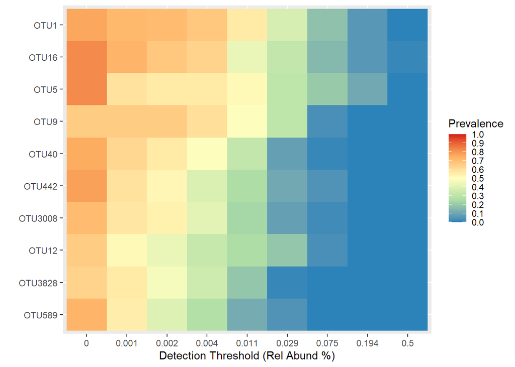

```r
# heatmap of core taxa by detection and prevalence
prevalences <- seq(from=0, to=1, by=0.1)
detections <-  round(10^seq(log10(1e-4), log10(0.5), length = 10), 3)

microbiome::plot_core(ps_core, plot.type = "heatmap",
           colours = rev(RColorBrewer::brewer.pal(5, "Spectral")),
           prevalences = prevalences,
           detections = detections) +
           ggplot2::labs(x = "Detection Threshold (Rel Abund %)")
```

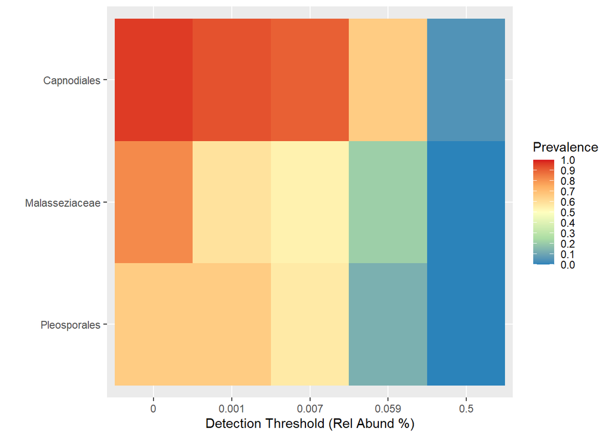

```r
# heat map with core taxa aggregated by Order
ps_core_order <- microbiome::aggregate_taxa(ps_core, "Order")

prevalences <- seq(0.05, 1, 0.05)
detections <-  round(10^seq(log10(1e-4), log10(0.5), length = 5), 3)

microbiome::plot_core(ps_core_order, plot.type = "heatmap",
           colours = rev(RColorBrewer::brewer.pal(5, "Spectral")),
           prevalences = prevalences,
           detections = detections) +
           ggplot2::labs(x = "Detection Threshold (Rel Abund %)")
```

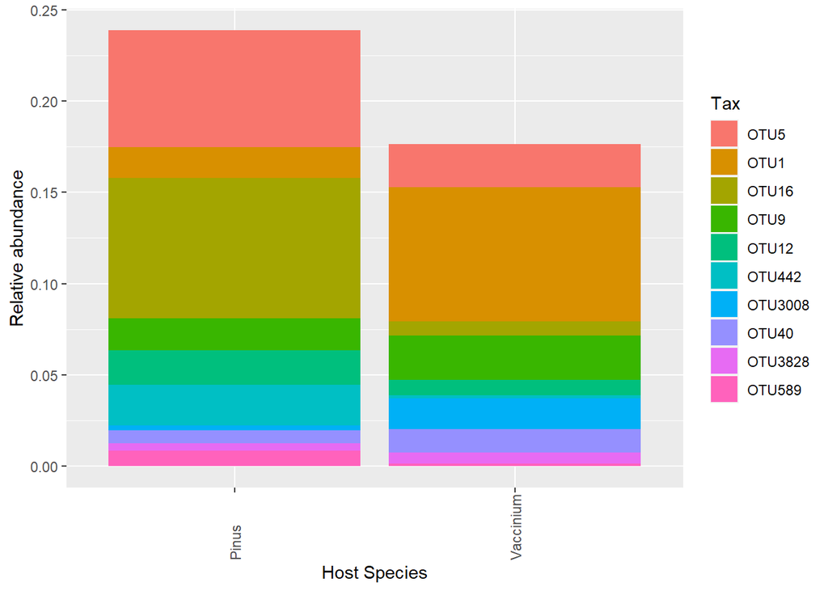

```r
# barplot of core taxa by host plant species
microbiome::plot_composition(ps_core,
                             average_by="Species",
                             plot.type = "barplot",
                             sample.sort="Species") +
                 guides(fill = guide_legend(ncol = 1)) +
                 labs(x = "Host Species",
                 y = "Relative abundance")
```

### Alternative approach using abundance-occupancy (Shade)

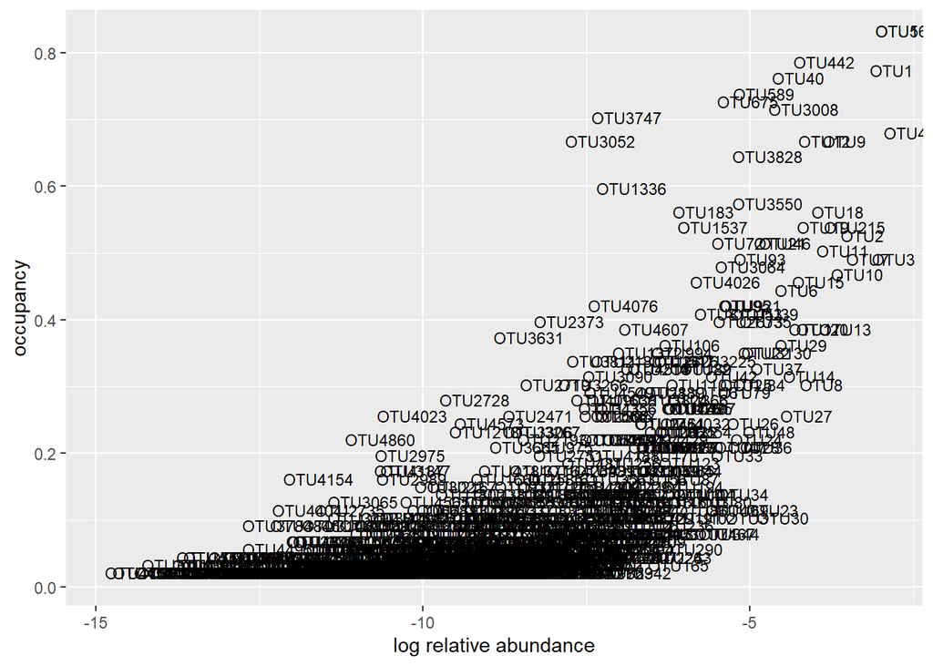

```r
# full approach is too extensive for class
# below is the code to make abundance-occupancy curves from the data
# Shade lab has posted R code for full procedure:
# https://github.com/ShadeLab/PAPER_Shade_CurrOpinMicro/blob/master/script/Core_prioritizing_script.R

# obtain otu table from ps object and transpose
otu <- phyloseq::otu_table(ps_nosing)

# some approaches require you to rarefy data, if so:
  # min_r <- min(sample_sums(ps_nosing))
  # min_r
  # otu_r <- rrarefy(otu, min_r)

# calculate occupancy and relative abundance
otu_pa <- 1*((otu>0)==1) # convert to pres-abs
otu_occ <- rowSums(otu_pa)/ncol(otu_pa) # calculate occupancy
otu_rel <- apply(vegan::decostand(otu, method="total", MARGIN=2), 1, mean) # mean rel abund

# merge files and rank by relative abundance
occ_abun <- dplyr::add_rownames(as.data.frame(cbind(otu_occ, otu_rel)), "otu")
oa_rank <- dplyr::arrange(occ_abun, otu_rel)
oa_rank_log <- oa_rank %>%
  dplyr::mutate(log_rel = log(otu_rel))

# create occupancy abundance plot with OTU labels
ggplot2::ggplot(oa_rank_log, aes(x=log_rel, y=otu_occ, label=otu)) +
  xlab("log relative abundance") +
  ylab("occupancy") +
  geom_text(hjust=0, vjust=0, size=3)
```

```r
# to better see in crowded plot, can try adding:
#  + geom_jitter()
# to read overlapping OTU names, can alternatively replace geom_text command with
#   geom_text_repel(size=3, min.segment.length=Inf, max.overlaps = Inf,  point.size=NA)
# but note this changes shape of the curve
```

# CODING EXERCISES

Please submit as a knitted html or pdf markdown to GitHub due on 3/9

### 1. Subset to Vaccinium unique OTUs and clr transform

- Goal is to retain only fungal OTUs found uniquely associated with Vaccinium by removing Pinus OTUs
- p1 venn diagram can help you to confirm expected numbers
- use `phylosmith::unique_taxa` to identify taxa associated only with Pinus in ps_nosing
  - https://schuyler-smith.github.io/phylosmith/analytics.html#unique_taxa
  - `devtools::install_github("schuyler-smith/phylosmith")`
  - `library(phylosmith)`  
    library(phylosmith)
- convert list to vector using base::unlist
  - https://www.rdocumentation.org/packages/base/versions/3.6.2/topics/unlist
  - note that this gives you unique Pinus OTUs + OTUs shared with Pinus
- export list of all taxa with `phyloseq::taxa_names` from ps_nosing
  - make new ps object ps_vacc by subsetting the list by removing taxa from Pinus
  - hint: look back at code from lulu
- in new ps object, ps_vacc
  - use remaining taxa list to retain only truly unique taxa with `phyloseq::prune_taxa`
  - use `phyloseq::subset_samples` to limit to Species==“Vaccinium”
  - check for and remove new singletons
- create ps_vacc_clr with clr transformed otu_table using `microbiome::transform`
- include new Vaccinium venn diagram by EcoType
- optional: if you have time and want to practice more, repeat for Pinus

### 2. Examine core microbiome for Vaccinium only

- for one detection and prevalence level, compare clr and rel abund data transforms
- vary detection and prevalence for clr data
  - adjust only detection up and down (at least 3 levels)
  - adjust only prevalence up and down (at least 3 levels)
- describe the effects on the size and characteristics of the core community
- optional: if you want more practice, repeat for Pinus

### 3. Identify the core microbiota of built-in `soilrep` data

- load built-in `soilrep` data and examine
- remove clipped samples with `phyloseq::subset_samples`
- remove singletons with `phyloseq::prune_taxa`
- identify core with `microbiome::core`
  - indicate why you selected your specific prevalence and detection settings
- produce a table of core ASVs using `kable` and specify column name
- plot results as heatmap, barplot, or other plot of your choice